# HW1_STAT GR5243

Hahyung Jung

2/2/2022

# install needed packages & Load the libraries and functions

```r
packages.used=c("dplyr", "tidyverse",
                "syuzhet", "tidytext", "tidyr",
                "scales", "ggplot2", "sqldf",
                "stringr", "tm", "readr",
                "widyr", "igraph", "ggraph")

packages.needed=setdiff(packages.used,
                        intersect(installed.packages()[,1],
                                  packages.used))

library("dplyr")
library("tidyverse")
library("syuzhet")
library("tidytext")
library("tidyr")
library("scales")
library("ggplot2")
library("sqldf")
library("stringr")
library("tm")
library("readr")
library("widyr")
library("igraph")
library("ggraph")
```

```r
print(R.version)
```

```
##                _
## platform       aarch64-apple-darwin20
## arch           aarch64
## os             darwin20
## system         aarch64, darwin20
## status
## major          4
## minor          1.1
## year           2021
## month          08
## day            10
## svn rev        80725
## language       R
## version.string R version 4.1.1 (2021-08-10)
## nickname       Kick Things
```

# Data harvest: scrap “THE PHILOSOPHY DATA PROJECT” csv file

```r
philosophy_data=read.csv("/Users/master/Desktop/IColud/Master/Columbia/Spring 2022/STAT GU 4243/Project 1/philosophy_data.csv", stringsAsFactors = FALSE)
```

# Scrap the texts of Philosophy from the csv file and Data Tokenization & Arrangement of the texts

```r
sentence_list <- select(philosophy_data, author, school, lemmatized_str)

text_tibble <- tibble(author = sentence_list$author, school = sentence_list$school, text = sentence_list$lemmatized_str)

sent_tokenized <- text_tibble %>%
  mutate(across(everything(), ~as.character(.))) %>%
  unnest_tokens(word, text)

tidy_words <- sent_tokenized %>%
  anti_join(stop_words) %>%
  filter(word != "pron")
```

# Data Processing - NRC Sentiment Anlaysis

We analyze positive & negative aspects about authors’ texts by using NRC sentiment anlaysis.

1. Inner join between NRC sentiments such as “positive” and “negative” and tokenized tidy words
2. Get each words’ sentiment ratio and Cacluate the sentiment ratio of each author
3. Display ggplot about each sentiment ratio of each author

$$The\ Sentiment \ Ratio = \frac{(Positive\ -\ Negative)}{(Positive\ +\ Negative)}$$

Author List

```r
author_type <- sqldf("select distinct author as 'author' from sentence_list")
author_type
```

```
##             author
## 1            Plato
## 2        Aristotle
## 3            Locke
## 4             Hume
## 5         Berkeley
## 6          Spinoza
## 7          Leibniz
## 8        Descartes
## 9      Malebranche
## 10         Russell
## 11           Moore
## 12    Wittgenstein
## 13           Lewis
## 14           Quine
```

[output cut: 22 more lines]

NRC Analysis

```r
nrc_anlaysis_pn <- tidy_words %>%
  inner_join(get_sentiments("nrc") %>%
               filter(sentiment %in% c("positive", "negative"))) %>%
  mutate(method = "NRC") %>%
  count(sentiment, author, sort = TRUE) %>%
  spread(sentiment, n, fill = 0) %>%
  mutate(sentiment_ratio = (positive - negative)/(positive + negative))
head(nrc_anlaysis_pn)
```

```
## # A tibble: 6 × 4
##   author    negative positive sentiment_ratio
##   <chr>        <dbl>    <dbl>           <dbl>
## 1 Aristotle    40225    65260          0.237
## 2 Beauvoir     18034    25507          0.172
## 3 Berkeley      2004     4621          0.395
## 4 Davis         4346     5127          0.0824
## 5 Deleuze      12166    18637          0.210
## 6 Derrida       5186     8935          0.265
```

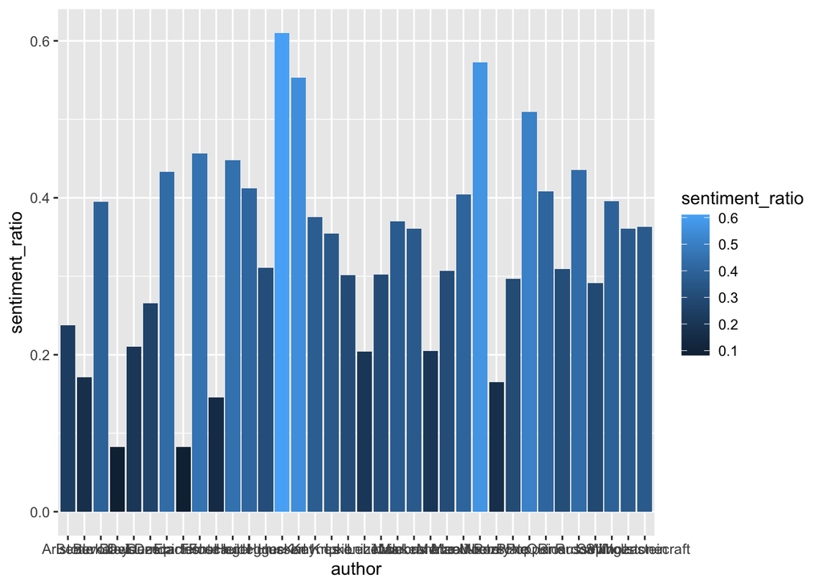

```r
ggplot(nrc_anlaysis_pn, aes(author, sentiment_ratio, fill=sentiment_ratio)) +
  geom_bar(stat="identity",position="identity")
```

```r
nrc_anlaysis_pn %>%
  summarise(mean_sentiment_ratio = mean(sentiment_ratio))
```

```
## # A tibble: 1 × 1
##   mean_sentiment_ratio
##                  <dbl>
## 1                0.336
```

We can derive this question by analyzing, “Do philosophers use positive or negative words more?”

# Data Processing - NRC Sentiment Anlaysis

We could categorize the sentiments on the schools’ texts and analyze the sentiment value of the texts of each school.

1. Inner join between NRC sentiments and tokenized tidy words [The type of sentiments in NRC : “anger”, “anticipation”, “disgust”, “fear”, “joy”, “sadness”, “surprise”, “trust”]
2. Get each words’ sentiment value and Calculate the value of each author about sentiments
3. Display ggplot about each sentiment ratio of each school

$$Freq\ Data = \frac{value's\ sum\ of\ each\ school}{all\ values'\ sum}$$
School Type

```r
school_type <- sqldf("select distinct school as 'school' from sentence_list")
school_type
```

```
##             school
## 1            plato
## 2        aristotle
## 3       empiricism
## 4      rationalism
## 5         analytic
## 6      continental
## 7    phenomenology
## 8  german_idealism
## 9        communism
## 10      capitalism
## 11        stoicism
## 12       nietzsche
## 13        feminism
```

```r
senti <- get_sentiments("nrc") %>%
  filter(sentiment != "positive" & sentiment != "negative")

text_tokenized_senti <- tidy_words %>%
  inner_join(get_sentiments("nrc") %>%
               filter(sentiment != "positive" & sentiment != "negative")) %>%
  count(school, sentiment, sort = TRUE)
text_tokenized_senti_ratio <-  text_tokenized_senti %>%
  group_by(school, sentiment) %>%
  summarise(value_sum = sum(n)) %>%
  mutate(freq_data = value_sum / sum(value_sum))
head(text_tokenized_senti_ratio)
```

```
## # A tibble: 6 × 4
## # Groups:   school [1]
##   school   sentiment    value_sum freq_data
##   <chr>    <chr>            <int>     <dbl>
## 1 analytic anger            11870    0.0907
## 2 analytic anticipation     23121    0.177
## 3 analytic disgust           7124    0.0544
## 4 analytic fear             14289    0.109
## 5 analytic joy              11666    0.0891
## 6 analytic sadness          12422    0.0949
```

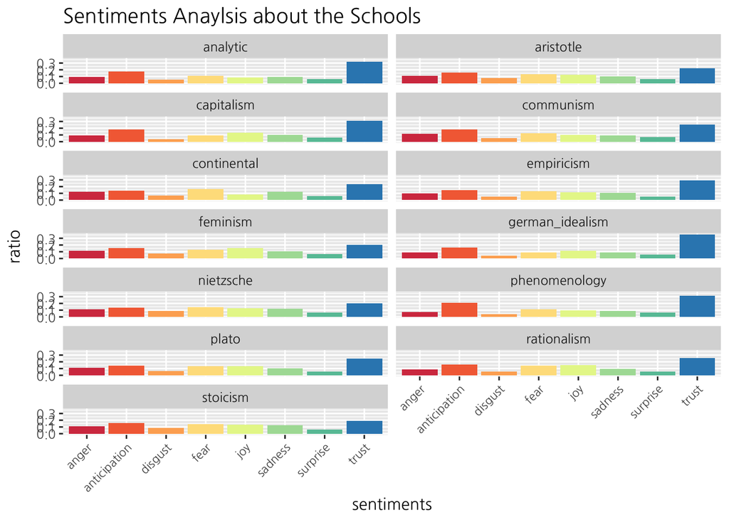

```r
ggplot(data=text_tokenized_senti_ratio, aes(x=sentiment, y=freq_data,
                                    fill=sentiment)) +
  geom_bar(stat="identity") +
  scale_fill_brewer(palette="Spectral") +
  guides(fill=FALSE) +
  facet_wrap(~ school, ncol=2) +
  theme(axis.text.x=element_text(angle=45, hjust=1, size=8),
        axis.title.y=element_text(margin=margin(0, 10, 0, 0)),
        plot.title=element_text(size=14)) +
  labs(y="ratio", x="sentiments",
       title="Sentiments Anaylsis about the Schools") +
  theme(text=element_text(family="NanumGothic"))
```

We can derive this question by analyzing, “what is the fundamental element of many emotional aspects in philosophical expressions?”

My answer is that trust is essential in the texts. Through the data, we can see the fact that every school’s ratio about trust is higher than other sentiments. It can be considered that philosophers have emphasized the ‘trust’ aspect in philosophical expressions many times.

# Data Analysis - TF-IDF & Examining Pairwise Correlation

First, we could make term frequency combine to calculate a term’s tf-idf (the two quantities multiplied together), the frequency of a term adjusted for how rarely it is used. It is to find the important words for the content of each document by decreasing the weight for commonly used words and increasing the weight for words that are not used very much in a collection or corpus of documents.

Second, we could discover this by finding the pairwise correlation of word frequencies within each school’s texts, using the pairwise_cor() function from the widyr package. Through the correlation of each schools, we could link to each school having higher than the 0.6 value of correlation.

$$idf\ (term) = ln(\frac{n(documents)}{n(documents\ cotaining\ term)})$$

```r
tidy_words_school <- tidy_words %>%
  count(school, word, sort = TRUE) %>%
  ungroup()

text_tokenized_total <- tidy_words_school %>%
  count(school, word, sort = TRUE) %>%
  ungroup() %>%
  group_by(school) %>%
  summarize(total = sum(n))

text_tokenized_sort <- left_join(tidy_words_school, text_tokenized_total)
text_tokenized_sort <- text_tokenized_sort %>%
  bind_tf_idf(word, school, n)

text_tokenized_sort %>%
  select(-total) %>%
  arrange(desc(tf_idf))
```

```
## # A tibble: 190,169 × 6
##    school          word                n      tf   idf  tf_idf
##    <chr>           <chr>           <int>   <dbl> <dbl>   <dbl>
##  1 nietzsche       zarathustra       626 0.00636 1.47  0.00932
##  2 stoicism        doth              247 0.0130  0.619 0.00803
##  3 phenomenology   dasein           1634 0.00678 1.18  0.00799
##  4 stoicism        thou              798 0.0419  0.167 0.00700
##  5 communism       capitalist        992 0.00558 1.18  0.00657
##  6 german_idealism determinateness  1318 0.00318 1.87  0.00596
##  7 stoicism        thee              306 0.0161  0.368 0.00591
##  8 stoicism        thy               338 0.0178  0.262 0.00466
##  9 analytic        counterfactual    672 0.00180 2.56  0.00463
## 10 phenomenology   sein              744 0.00309 1.47  0.00453
## # … with 190,159 more rows
```

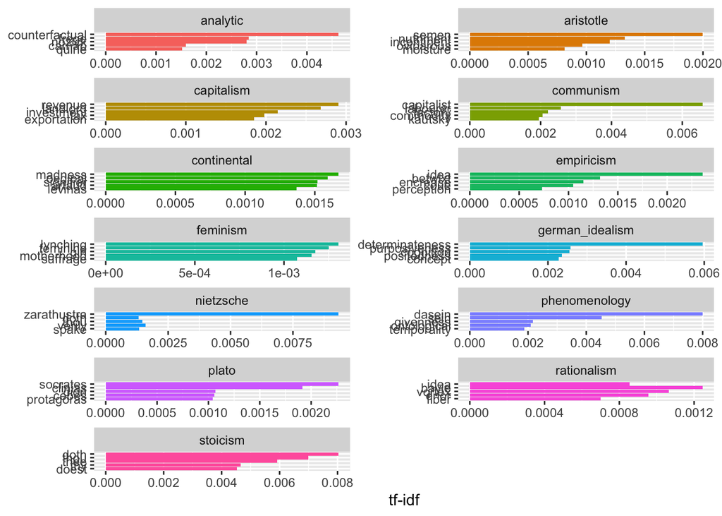

```r
text_tokenized_sort %>%
  arrange(desc(tf_idf)) %>%
  mutate(word = factor(word, levels = rev(unique(word)))) %>%
  group_by(school) %>%
  top_n(5) %>%
  ungroup %>%
  ggplot(aes(word, tf_idf, fill = school)) + geom_col(show.legend = FALSE) +
  labs(x = NULL, y = "tf-idf") +
  facet_wrap(~school, ncol = 2, scales = "free") + coord_flip()
```

```r
school_cors <- text_tokenized_sort %>%
  pairwise_cor(school, word, n, sort = TRUE)

school_cors
```

```
## # A tibble: 156 × 3
##    item1           item2           correlation
##    <chr>           <chr>                 <dbl>
##  1 rationalism     empiricism            0.738
##  2 empiricism      rationalism           0.738
##  3 continental     phenomenology         0.643
##  4 phenomenology   continental           0.643
##  5 analytic        phenomenology         0.635
##  6 phenomenology   analytic              0.635
##  7 plato           aristotle             0.630
##  8 aristotle       plato                 0.630
##  9 phenomenology   german_idealism       0.624
## 10 german_idealism phenomenology         0.624
## # … with 146 more rows
```

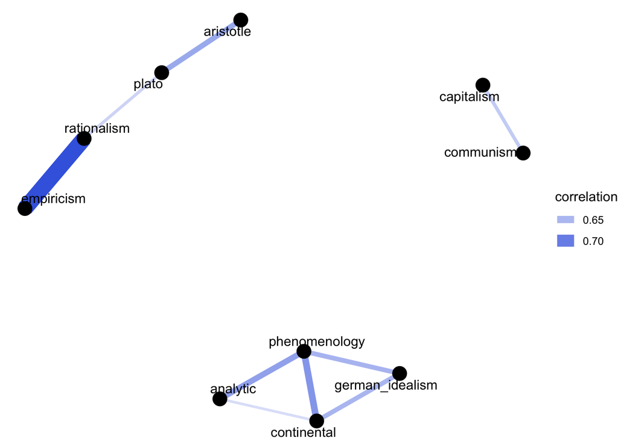

```r
school_cors %>%
  filter(correlation > .6) %>%
  graph_from_data_frame() %>%
  ggraph(layout = "fr") +
  geom_edge_link(aes(edge_alpha = correlation, edge_width = correlation),
                 edge_colour = "royalblue") +
  geom_node_point(size = 5) +
  geom_node_text(aes(label = name), repel = TRUE, point.padding = unit(0.2, "lines")) +
  theme_void()
```

We can derive this question by analyzing, “What schools tend to be similar to each other in text contents?”

The answer is that we can discover the three clusters. The clusters have strong correlation over 0.6.